Objective: Inhaled anticoagulation regimens are increasingly being

used to manage smoke inhalation–associated acute lung injury.

We systematically reviewed published and unpublished preclini-

cal and clinical trial data to elucidate the effects of these regimens

on lung injury severity, airway obstruction, ventilation, oxygenation,

pulmonary infections, bleeding complications, and survival.

Data Sources: PubMed, Scopus, EMBASE, and Web of Science

were searched to identify relevant published studies. Relevant

unpublished studies were identified by searching the Australian

and New Zealand Clinical Trials Registry, World Health Organi-

zation International Clinical Trials Registry Platform, Cochrane

Library, ClinicalTrials.gov, MINDCULL.com, Current Controlled

Trials, and Google.

Study Selection: Inclusion criteria were any preclinical or clinical

study in which 1) animals or subjects experienced smoke inhala-

tion exposure, 2) they were treated with nebulized or aerosolized

anticoagulation regimens, including heparin, heparinoids, anti-

thrombins, or fibrinolytics (e.g., tissue plasminogen activator), 3)

a control and/or sham group was described for preclinical stud-

ies, and 4) a concurrent or historical control group described for

clinical studies. Exclusion criteria were 1) the absence of a group

treated with a nebulized or aerosolized anticoagulation regimen,

2) the absence of a control or sham group, and 3) case reports.

Data Extraction: Ninety-nine potentially relevant references were

identified. Twenty-seven references met inclusion criteria includ-

ing 19 preclinical references reporting 18 studies and eight clini-

cal references reporting five clinical studies.

Data Synthesis: A systematic review of the literature is provided.

Both clinical and methodological diversity precluded combining

these studies in a meta-analysis.

Conclusions: The high mortality associated with smoke inhalation–

associated acute lung injury results from airway damage, mucosal

dysfunction, neutrophil infiltration, airway coagulopathy with cast

formation, ventilation-perfusion mismatching with shunt, and baro-

trauma. Inhaled anticoagulation regimens in both preclinical and

preclinical and clinical studies, inhaled anticoagulants were asso-

ciated with a favorable effect on survival. This approach appears

sufficiently promising to merit a well-designed prospective study

to validate its use in patients with severe smoke inhalation–associ-

ated acute lung injury requiring mechanical ventilation. (*Crit Care*

*Med* 2014; 42:413–419)

Key Words: acute lung injury; anticoagulants; antithrombins;

fibrinolytic agents; heparin; smoke inhalation injury

I

n the United States, more than 450,000 burn injuries occur

annually (1). Smoke inhalation–associated acute lung

injury (SI-ALI) constitutes a major cause of morbidity

and mortality in victims of fire tragedies, affecting nearly 1.5–

19.5% of burn patients worldwide (1.5% Israel, 8% China, and

19.5% United States) (2–4). The prevalence of SI-ALI is cor-

related with a greater percent of burn surface area (BSA) (3);

however, significant SI-ALI may exist in the absence of cutane-

ous burns. When combined with cutaneous burns, inhalation

injury increases fluid requirements for resuscitation, the preva-

lence of pulmonary complications, and the mortality rate (3,

5–8). In a retrospective analysis of 573 burn patients admitted

*See also p. 474.

1Department of Critical Care Medicine, Clinical Center, National Institutes

of Health, Bethesda, MD.

2Department of Internal Medicine, Division of Pulmonary, Allergy, and Criti-

cal Care, University of Pittsburgh Medical Center, Pittsburgh, PA.

3Department of Internal Medicine, Division of Pulmonary, Critical Care,

and Sleep Medicine, James A. Haley Veteran’s Hospital and University of

South Florida, Tampa, FL.

All authors contributed to all stages of manuscript planning, research,

preparation, and revision.

Supplemental digital content is available for this article. Direct URL cita-

tions appear in the printed text and are provided in the HTML and PDF

versions of this article on the journal’s website (http://journals.lww.com/

ccmjournal).

Supported, in part, by the Intramural Research Program of the Clinical

Center, National Institutes of Health, and the Veterans Administration

Hospital.

Dr. Elamin received support for travel from SuperDimension. Dr. Suffredini

received support for article research from the National Institutes of Health.

Dr. Miller disclosed that he does not have any potential conflicts of interest.

For information regarding this article, E-mail: andrew.miller3@nih.gov

Copyright © 2013 by the Society of Critical Care Medicine and Lippincott

Williams & Wilkins

**DOI: 10.1097/CCM.0b013e3182a645e5**

Inhaled Anticoagulation Regimens for the

Treatment of Smoke Inhalation–Associated Acute

Lung Injury: A Systematic Review*

Andrew C. Miller, MD<sup>1,2</sup>; Elamin M. Elamin, MD, MSc<sup>3</sup>; Anthony F. Suffredini, MD<sup>1</sup>

over a 4-year period to a regional burn center, patients with

inhalation injury had a more than 70% prevalence of respi-

ratory failure (hypoxemia, multiple pulmonary infections, or

prolonged ventilatory support) and a 20% prevalence of acute

respiratory distress syndrome (9). The reported mortality

associated with SI-ALI ranges from 11% to 80% (3, 4, 8–11).

The variability in mortality rates from different regions of the

world and time periods likely reflects the heterogeneity of the

patient populations due to age, comorbidities, severity of the

primary and secondary injuries, and variations in therapy.

Several mechanisms have been identified in animal models

and in human pathologic studies that contribute to the develop-

ment of SI-ALI. Smoke inhalation promotes airway damage and

inflammation. Immediately following smoke inhalation, bron-

chial blood flow increases up to 20-fold (12). Increased microvas-

cular permeability and airway edema results in plasma exudation

into the airway resulting in intra-airway coagulation and fibrin

deposition. Cellular debris, mucin, and fibrin deposition admix

to form a fibrinocellular exudate or pseudomembranes that may

develop into obstructive airway casts that promote significant

mismatch in ventilation and perfusion (V/Q) (2, 13–23). The

V/Q mismatch is further worsened by increased perfusion to

underventilated lung regions due to impaired hypoxic vasocon-

striction driven in part by increased nitric oxide production (24,

25). Furthermore, partially obstructed airways may result in air

trapping and alveolar hyperinflation via a ball-valve mechanism

that may promote distal airway and alveolar damage. These

mechanisms may lead to impaired oxygenation and ventilation.

Although on mechanical ventilation this may result in elevated

peak and plateau pressures, auto-peep, and patient-ventilator

dyssynchrony, this may promote regional barotrauma in some

lung segments while resulting in repetitive alveolar collapse and

expansion injury. Additionally, casts may also occlude endotra-

cheal and tracheostomy tubes necessitating emergent airway

revision (26).

SI-ALI is an important yet understudied clinical problem.

The use of inhaled anticoagulation regimens is increasingly

being used to manage SI-ALI with the goal of improving out-

comes by decreasing airways fibrin deposition and obstruction

(27). However, the data detailing the efficacy of this approach

are limited and to our knowledge has not been compiled into

a comprehensive review. We conducted this review to sum-

marize the complex body of literature on the topic, assess the

consistency of results across trials, clarify the strengths and

weakness of available studies, and document the need for fur-

ther prospective clinical investigation. We systematically review

published and unpublished preclinical and clinical study data

to elucidate the effects of such regimens on lung injury sever-

ity, airway obstruction, ventilation, oxygenation, pulmonary

infections, bleeding complications, and survival.

**METHODS**

A systematic search was performed to capture published and

unpublished preclinical and clinical studies of nebulized anti-

coagulation regimens as treatment for SI-ALI. PubMed, Sco-

pus, EMBASE, and Web of Science were searched to identify

relevant published studies. The search strategies were adapted

to accommodate the unique searching features of each data-

base, including database-specific MESH and EMTREE con-

trolled vocabulary terms. Searches were not limited by date,

language, or publication status. See **Appendix 1** (Supple-

mental Digital Content 1, http://links.lww.com/CCM/A741)

for detailed search strategies. The cited and citing references

of selected studies were also searched for additional relevant

material.

To minimize publication bias, relevant unpublished stud-

ies were identified by searching the Australian and New

Zealand Clinical Trials Registry, World Health Organization

International Clinical Trials Registry Platform, Cochrane

Library,

ClinicalTrials.gov,

MINDCULL.com,

Current

Controlled Trials, and Google.

Inclusion criteria were any preclinical or clinical study in

which 1) animals or subjects experienced smoke inhalation

exposure, 2) they were treated with nebulized or aerosolized

anticoagulation regimens, including heparin, heparinoids,

antithrombins (ATs), or fibrinolytics (e.g., tissue plasminogen

activator, TPA), 3) a control and/or sham group was described

for preclinical studies, and 4) a concurrent or historical control

group described for clinical studies. Exclusion criteria were 1)

the absence of a group treated with a nebulized or aerosolized

anticoagulation regimen, 2) the absence of a control or sham

group, and 3) case reports.

**RESULTS**

The search identified 99 potentially relevant studies. Twenty-

seven references met inclusion criteria (**Fig. 1**), including 19

preclinical references reporting 18 studies and eight clinical

references reporting five clinical studies. One prospective

clinical trial has been planned, but results are not available

(28). The presence of both clinical diversity and method-

ological diversity precluded combining the study reports in a

meta-analysis.

99 poten�ally

relevant references

71 references

excluded

27 studies mee�ng

inclusion criteria

8 human study

references

19 animal study

references

13 abstract

only

6 full

manuscripts

5 abstract

only

3 full

manuscripts

12 Studies

1 Duplicate

Publica�on

0 Duplicate

Publica�ons

3 Duplicate

Publica�ons

0 Duplicate

Publica�ons

6 Studies

2 Studies

3 Studies

1 human study

in progress

**Figure 1.** Schematic summary of literature review of nebulized anticoagu-

lation regimens for the treatment of smoke inhalation–associated acute

lung injury.

**Preclinical Studies**

The bulk of the preclinical studies were conducted using an ovine

model of SI-ALI. In this model, the sheep are surgically prepared

for chronic study via placement of arterial, left atrial, pulmonary

artery, and lung lymphatic catheters. On postoperative days 5–7,

smoke inhalation exposure is accomplished via either cooled cot-

ton (< 40°C) (13, 29–45) or pinewood (46) smoke administered

via tracheostomy or endotracheal tube. In most models, the ani-

mals undergo cutaneous thermal burn (40% BSA) at the time

of smoke exposure. The animals are mechanically ventilated and

volume resuscitated with IV crystalloid infusion in accordance

with the Parkland formula (47). Antibiotic therapy is not admin-

istered. The most commonly investigated nebulized anticoagula-

tion regimens include unfractionated heparin (5,000 or 10,000

IU), AT (290 U), and TPA (1 or 2 mg) either alone or in combina-

tion with anticoagulants. Depending on the study and treatment

regimen, nebulized therapies are initiated at 1–4 hours postin-

jury and continued every 4 hours for, commonly, 24–48 hours.

Endpoints are reported from 48 to 96 hours postinjury and

usually include mortality, weaning from mechanical ventilation,

and tracheostomy decannulation. Commonly reported markers

of ventilation and oxygenation include peak and plateau airway

pressures, PaO2/FIO2, and arterial-alveolar oxygen gradient. Mark-

ers of pulmonary congestion and obstruction include the lung

wet-to-dry ratio (W/D), lung lymph flow, pulmonary shunt

fraction (Qs/Qt), and histological obstruction scores. Other

endpoints include the results of blood coagulation and clotting

cascade variables and fluid balance. **Appendix 2** (Supplemental

Digital Content 1, http://links.lww.com/CCM/A741) summa-

rizes the results of 18 preclinical studies assessing inhaled antico-

agulation regimens as treatment for SI-ALI.

Characteristic findings of SI-ALI as described by findings

from control groups include the following: increased mortal-

ity and impaired ventilation with elevations in peak and pla-

teau airway pressures, decline in PaO2/FIO2 with concomitant

rise in arterial-alveolar gradient, and increased evidence of

airway obstruction. Increasing pulmonary congestion is often

manifested as an increase in lung lymph flow, Qs/Qt, and W/D.

With few exceptions, nebulized anticoagulation regimens sig-

nificantly attenuated these findings (**Table 1).**

**TabLE 1.** **Summary of the Pathophysiological Effects of Nebulized anticoagulation**

**Regimens in animal Models of Smoke Inhalation–associated acute Lung Injury**

**Reference**

**Inhaled**

**antico-**

**agulation**

**Regimen**

**Pa****O****2****/F****IO****2**

**Ratio**

**alveolar**

**to arterial**

**Gradient**

**Shunt**

**Fraction**

**Qs/Qt**

**Wet-to-Dry**

**Ratio**

**Lymph**

**Flow**

**airway**

**Pressures**

**Histological**

**Obstruction Survival**

Characteristic findings in

smoke inhalation–associate

acute lung injury

↓

↑

↑

↑

↑

↑

↑

↓

Desai et al (29)

1, 5

↓

↑

Brown et al (30)<sup>a</sup>

1, 5

↑

Cindric et al (31)

4

↓

Katahira et al (32)

1

↑

↓

Murakami et al (34)

1

↑

↓

↓

↓

Tasaki et al (46)

1

↓

No change

↓

Enkhbaatar et al (13)

1, 3, 6

↑

↓

↓

↓

↓

Enkhbaatar et al (36)

2, 6

↓

↓

↓

Nakano et al (37)

7

↑

↓

Enkhbaatar et al (38)

1, 3, 6

↑

↓

↓

↓

↓

Enkhbaatar et al (39)

7

↑

↑

↓

↓

↓

↓

Rehberg et al (40)

8

↓

↓

↓

Asmussen et al (41)

8

↑

↑

Rehberg et al (42)

8

↑

↓

↓

Asmussen et al (45)

8

↑

↑

Rehberg et al (44)

8

↑

↓

↓

aDue to high mortality in control and DMSO-alone groups, further comparisons were only made between heparin and DMSO + heparin groups.

For studies presented, arrows indicate change from control or untreated groups, not overall change from baseline.

Inhaled anticoagulation regimens: 1, heparin inhaled; 2, tissue plasminogen activator (tPA) inhaled; 3, antithrombin (AT) inhaled; 4, GM 1892 inhaled; 5, heparin

inhaled + dimethyl sulfoxide inhaled; 6, heparin inhaled + AT inhaled; 7, heparin inhaled + AT IV; 8, heparin inhaled + tPA inhaled + AT IV.

**Clinical Studies**

Eight references accounting for five human clinical studies were

identified (**Table 2**). Additionally, a prospective human study

is planned but not yet recruiting patients (ClinicalTrials.gov

#NCT014548690) (28). All human studies conducted to date

have been retrospective studies with historical controls. Four

of the five studies were conducted around a change in institu-

tional protocol (2, 27, 48, 49). Three studies assessed a low-dose

heparin protocol (5,000 IU) (2, 49, 50) of which one treated

according to physician discretion (50), and two studies assessed

a high-dose heparin regimen (10,000 IU) (27, 48). The impact of

the nebulized heparin protocols on common primary endpoints

is summarized in **Table 3**. Both studies assessing a standardized

high-dose heparin dosing regimen (10,000 IU nebulized every

4 hr) reported statistically significant mortality improvement

(27, 48). Conversely, the one study that did not report a mortal-

ity benefit used a low-dose regimen, and unlike the aforemen-

tioned studies, suffered from significant selection bias in that

patients were not allocated into treatment groups but instead

**TabLE 2.** **Summary of Human Clinical Investigations of Inhaled anticoagulation for Smoke**

**Inhalation–associated acute Lung Injury**

**Reference**

*n*

**Protocol**

**Intervention**

**Results**

Desai et al

(2)

90

Retrospective

analysis with

historical control

Standard therapy + heparin 5,000 U

inhaled alternating with 3 mL NAC

inhaled every 2 hr for first 7 d

following injury

↓ Mortality, ↓ reintubation rate,

↓ prevalence pneumonia and

atelectasis; no significant

change in duration of intubation

Rivero et al

(48)<sup>a</sup>

16

Retrospective

analysis with

historical control

The nebulized heparin 10,000

IU + NAC 3 mL of 20% group

consisted of nine patients with

smoke inhalation acute lung injury

diagnosed with bronchoscopy and

necessitating mechanical ventilation

and Acute Physiology and Chronic

Health Evaluation III score > 35

(mean 46.66 vs 44.86 [control],

*p* = 0.38); additionally, daily Lung

Injury Score was calculated for 7 d

and was determined by averaging the

scores of chest radiograph, Pao2/FIo2,

positive end-expiratory pressure, and

respiratory system compliance

In the first two ICU days, mean

lung injury scores were

significantly lower in the

lung injury score during the

first week was 0.91 ± 0.14 vs

1.79 ± 0.41 (*p* < 0.01) for NH-

NA and non-nebulized heparin

and NAC patients, respectively;

mortality was 11% (1/9) in the

treatment group and 43% of

patients (3/7) in the control

group during the first ICU week

Holt et al

(50)

150

Retrospective

analysis with

historical control

No patient allocation; patients treated

according to attending discretion;

treated patients received inhaled

heparin 5,000 U/1 mL, NAC 3 mL

20% solution, and albuterol 2.5 mg

of 0.083% solution (3 mL) every 4 hr

for the first 7 d following admission

or until extubation

No significant difference in

mortality, duration of mechanical

ventilation, length-of-stay, or

pneumonia

Miller et al

(27)

30

Retrospective

analysis with

historical control

Standard therapy + heparin 10,000 U

inhaled every 4 hr alternating with

NAC 3 mL of 20% + albuterol

0.5 mL every 4 hr

↓ Mortality, ↓ lung injury score

Yip et al (49)

63

Retrospective

analysis with

historical control

1. Treatment group: mechanically

ventilated adult patients with

bronchoscopically confirmed SI-ALI

admitted in a burn ICU (2006–

2009); treated with heparin 5,000

IU inhaled + NAC 600 mg/3 mL of

20% aerosolized solution inhaled +

salbutamol 5 mg inhaled, each every

4 hr (*n* = 52)

No significant difference in

trend of activated partial

thromboplastin time, prothrombin

time, and platelet count over 7 d;

no clinically significant increase

in bleeding risk in treatment

group

2. Control: mechanically ventilated

SI-ALI patients (2001–2005) before

protocol initiation

NAC = *N*-acetylcysteine, SI-ALI = smoke inhalation–associate acute lung injury.

aPublished as abstract.

significant improvement (2, 27, 48). Only one standardized

regimen (low dose) has assessed the prevalence of pneumonia,

and this study reported a significant decrease in the prevalence

of pneumonia (2). These results were not reproduced by the

study without a standardized dosing regimen (50). Although

no change in the duration of mechanical ventilation has been

reported with nebulized heparin regimens, one study did report

a decrease in the prevalence

of

unplanned

reintubation

(2). Similar to animal studies,

nebulized heparin regimens of

5,000 IU or 10,000 IU every 4

hours in humans have not been

shown to alter serum markers

of anticoagulation (49).

**DISCUSSION**

Much of what is known of the

early effects of smoke exposure

on the respiratory tract has

been described and validated

in numerous ovine and lapine

models of smoke inhalation

(51–54). Although difficult

to study in humans, the time

course of these physiological

effects is comparable to those

found in burned patients with

smoke inhalation injury (51).

Thermal inhalation injury

only rarely affects the intra-

thoracic airways (55). Unless

the patient is exposed to steam,

which has much greater heat

carrying capacity than dry air,

the heat dissipating properties

of the upper airway restrict

direct thermal injury to the

supraglottic structures (56,

57). Intrathoracic and lower

airway injury is most often

a chemical-associated injury

related to substances that have

**TabLE 3.** **Summary of the Pathophysiological and Clinical Effects of Nebulized Heparin**

**Regimens in Human Clinical Studies of Smoke Inhalation–associated acute Lung Injury**

**Reference**

**Lung Injury**

**Score**

**Pneumonia**

**Prevalence**

**Mechanical**

**Ventilation**

**Duration**

**Unplanned**

**Reintubation**

**Hospital Length**

**of Stay**

**bleeding Risk**

**Mortality**

Desai et al (2)

↓

↓

No change

↓

Rivero et al (48)

↓

↓

Holt et al (50)<sup>a</sup>

No change

No change

No change

Miller et al (27)

↓

↓

Yip et al (49)

No change

aNo randomization or allocation into treatment groups. Patients treated at attending physician discretion with a dosing regimen half the strength of the studies by

Rivero et al (48) and Miller et al (27).

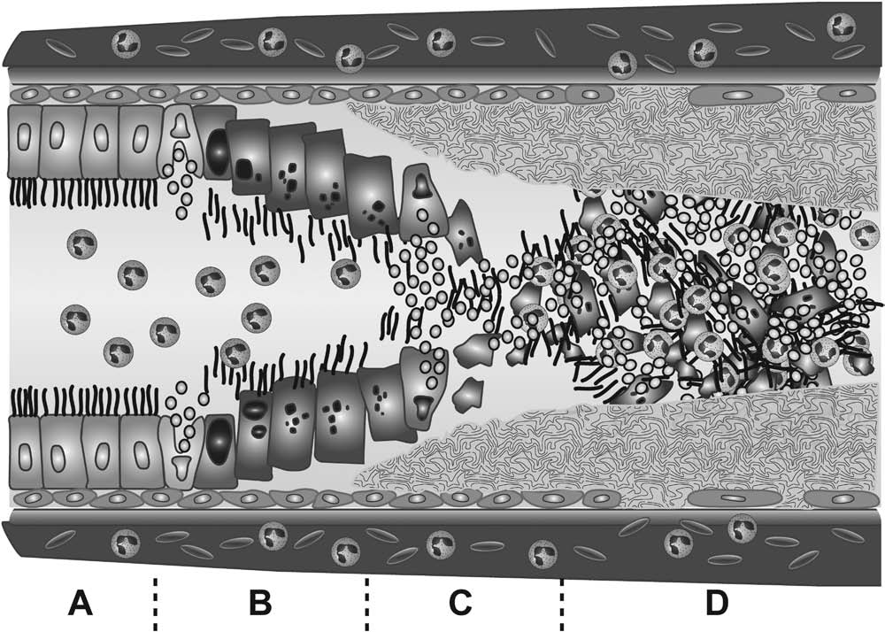

**Figure 2.** Depiction of airway changes in the setting of smoke inhalation–associated acute lung injury. Trachea

and bronchi injury is characterized by mucosal hyperemia, increased microvascular permeability, exfoliation of

the epithelial lining, mucous secretion, and an acute inflammatory cell influx (**a–C**) (57). As early as 1 hr postex-

posure, affected respiratory tract epithelium may display clumping, swelling, loss of cilia, blebbing, and surface

erosion (B) (55). Within hours, sloughing of the respiratory mucosa progresses, a fibrinocellular pseudomem-

brane begins to form, and neutrophils begin to influx into the major airways (55). By 6 hr postinjury, the injured

bronchi and bronchiole epithelium remains largely intact with focal areas of necrosis and sloughing (A, B) (56).

Surface lining cells appear enlarged with cytoplasmic vacuolization, and neutrophils have begun to marginate

and focally concentrate at points of epithelial necrosis (56). In addition, basal cells are normal in appearance,

and the subepithelial connective tissue may appear slightly edematous with contained neutrophil infiltrates (56).

By 24 hr, the ciliated and secretory lining cells are largely destroyed (C) (56). Cellular debris is admixed with

fibroid material, mucus, and neutrophils creating a pseudomembranous fibrinocellular network that is adherent

to both the cell-denuded basal lamina and the intact basal cells (C, **D**) (56). By 72 hr, injured epithelial areas

are largely resurfaced by a stratified reparative epithelium with interposed areas of fibrinocellular exudate (D)

(56). This epithelium is three to five cells thick, with flattened, nonciliated cells along the surface, and these cells

are likely derived from proliferating and migrating basal cells (56). Subepithelial edema and inflammatory cell

infiltrates begin to diminish (56). Complete repair of the respiratory tract epithelium with return of normal cilia

populations may take up to 2–4 wk depending on the severity of smoke exposure.

lower water solubility and particles less than 5 microns in

diameter (58).

Inhaled toxicants can be in the form of gases, vapors, partic-

ulate matter, and aerosols (57). Smoke from combustible mate-

rial contains a variety of toxic substances that may cause direct

cell injury and initiate inflammatory responses that propagate

airway damage (55, 57, 58). Additionally, inhaled particulate

matter (i.e., soot) may have adsorbed toxic molecules on the

surfaces and sustain inflammatory responses when adherent to

the airway mucosa (57).

The initial injury from smoke inhalation is limited to the tra-

chea and bronchi and is characterized by mucosal hyperemia,

increased microvascular permeability, exfoliation of the epithe-

lial lining, mucous secretion, and an acute inflammatory cell

influx (**Fig. 2** *A***–***C***)** (53). Necrosis and sloughing of tracheal epi-

thelium has been reported as early as 15 minutes postexposure

(51). Bronchi obstruction peaks as early as 24 hours, whereas

bronchiolar obstruction progressively increases to reach a max-

imum by 72 hours (**Fig. 2***D***)** (51, 53). This may be in part due to

obstructive material that migrates distally from larger airways

to smaller bronchioles and disruption of mucociliary clearance

(53). As highlighted in Figure 2, fundamental to the airway

obstruction is the role of increased microvascular permeabil-

ity and airway edema that results in plasma exudation into the

airway producing intra-airway coagulation and fibrin deposits.

These deposits lead to with the resultant fibrinocellular pseu-

domembranes composed of fibrin deposition, cellular debris,

and mucin. A dose-dependent relationship between degree of

smoke exposure and severity of injury has been described (55).

As intra-airway coagulation with fibrin deposition and fibrino-

cellular pseudomembranes begin to form within hours of smoke

exposure, inhaled anticoagulation regimens may be most effec-

tive when initiated early under the premise that impairing fibrin

clot deposition may decrease airway cast formation and improve

oxygenation and ventilation while decreasing the risk of baro-

trauma. Preclinical models (Appendix 2, Supplemental Digital

Content 1, http://links.lww.com/CCM/A741) most commonly

Human studies did not reliably report time from smoke exposure

to treatment initiation. Based on preclinical studies, it may be rea-

sonable to initiate a regimen of inhaled heparin within 4 hours

postexposure (or as early as possible) and to continue it every 4

hours for 48 hours. In animal models, 72 hours injured epithelial

areas are largely resurfaced by a stratified reparative epithelium

with only interposed areas of fibrinocellular exudate (Fig. 2*D*)

(52). Additional factors that contribute to airway cast formation

are mucus secretion and the presence of a large burden of cellular

debris. The addition of the mucolytic *N*-acetylcysteine to nebu-

lized heparin regimens intervenes at an additional level to pre-

vent or minimize formation of obstructive airway casts (2, 27, 48,

59). Future studies in SI-ALI may use combination therapy with

inhaled heparin, an inhaled fibrinolytic (e.g., TPA), and muco-

lytic therapy (e.g., *N*-acetylcysteine). Furthermore, recombinant

human deoxyribonuclease I (dornase alfa) cleaves extracellular

DNA in mucous and when inhaled reduces the adhesiveness and

viscoelasticity of airway mucous in patients with cystic fibrosis

(60). This treatment might augment the breakdown of cellular

debris and further impede the formation of fibrinocellular pseu-

domembranes. However, to date, no studies using this strategy in

the setting of SI-ALI have been reported.

**CONCLUSION**

The high mortality associated with SI-ALI results from airway

epithelial cell injury and inflammation, mucosal dysfunction,

airway coagulopathy with cast formation resulting in ventila-

tion-perfusion mismatch with shunt, and barotrauma. Inhaled

anticoagulation regimens in both preclinical and clinical stud-

ies decrease morbidity without altering systemic markers of

clotting and anticoagulation. In some preclinical and clinical

studies, inhaled anticoagulants were associated with a favorable

effect on survival. This approach appears sufficiently promising

to merit a well-designed prospective study to validate its use in

patients with severe SI-ALI requiring mechanical ventilation.

**aCKNOWLEDGMENTS**

We thank Judith Welsh for her assistance and expertise with the

literature search and search strategies. Additionally, we thank

Kelly Byrne for her assistance in developing the artwork.

**REFERENCES**

1. Association AB: Burn incidence and treatment in the United States:

2011 Fact Sheet. American Burn Association National Burn

Repository (2011 report) 2011. Available at: http://www.ameriburn.

org/resources_factsheet.php. Accessed November 14, 2012

2. Desai MH, Mlcak R, Richardson J, et al: Reduction in mortality in pedi-

atric patients with inhalation injury with aerosolized heparin/N-acet-

ylcystine [correction of acetylcystine] therapy. *J Burn Care Rehabil*

1998; 19:210–212

3. Luo G, Peng Y, Yuan Z, et al: Inhalation injury in southwest China—The

evolution of care. *Burns* 2010; 36:506–510

4. Thompson PB, Herndon DN, Traber DL, et al: Effect on mortality of

inhalation injury. *J Trauma* 1986; 26:163–165

5. Dai NT, Chen TM, Cheng TY, et al: The comparison of early fluid ther-

apy in extensive flame burns between inhalation and noninhalation

injuries. *Burns* 1998; 24:671–675

6. Suzuki M, Aikawa N, Kobayashi K, et al: Prognostic implications of

inhalation injury in burn patients in Tokyo. *Burns* 2005; 31:331–336

7. Tredget EE, Shankowsky HA, Taerum TV, et al: The role of inhala-

tion injury in burn trauma. A Canadian experience. *Ann Surg* 1990;

212:720–727

8. Shirani KZ, Pruitt BA Jr, Mason AD Jr: The influence of inhalation injury

and pneumonia on burn mortality. *Ann Surg* 1987; 205:82–87

9. Hollingsed TC, Saffle JR, Barton RG, et al: Etiology and conse-

quences of respiratory failure in thermally injured patients. *Am J Surg*

1993; 166:592–596

10. Mlcak RP: Aerosolized heparin/N acetylcystine treatment of smoke

inhalation injury in 596 burned children: A 15 year review, 1990–

2005. Saliba MJ (Ed). 6th International Heparin in Burns Symposium.

Shanghai, China, 2005

11. Blinn DL, Slater H, Goldfarb IW: Inhalation injury with burns: A lethal

combination. *J Emerg Med* 1988; 6:471–473

12. Stothert JC Jr, Ashley KD, Kramer GC, et al: Intrapulmonary distribu-

tion of bronchial blood flow after moderate smoke inhalation. *J Appl*

*Physiol* 1990; 69:1734–1739

13. Enkhbaatar P, Murakami K, Westphal M, et al: Combined antithrombin

and heparin nebulization improves pulmonary function in sheep with

burn and smoke inhalation: 96. *Crit Care Med* 2004; 32:A24

14. Jacob S, Kraft R, Zhu Y, et al: Acute secretory cell toxicity and epi-

thelial exfoliation after smoke inhalation injury in sheep: An elec-

tron and light microscopic study. *Toxicol Mech Methods* 2010;

20:504–509

15. Choi WI, Syrkina O, Kwon KY, et al: JNK activation is responsible for

mucus overproduction in smoke inhalation injury. *Respir Res* 2010;

11:172

16. Cox RA, Burke AS, Traber DL, et al: Production of pro-inflammatory

polypeptides by airway mucous glands and its potential significance.

*Pulm Pharmacol Ther* 2007; 20:172–177

17. Morita N, Enkhbaatar P, Maybauer DM, et al: Impact of bronchial cir-

culation on bronchial exudates following combined burn and smoke

inhalation injury in sheep. *Burns* 2011; 37:465–473

18. Hill IR: Reactions to particles in smoke. *Toxicology* 1996; 115:

119–122

19. Murakami K, Traber DL: Pathophysiological basis of smoke inhalation

injury. *News Physiol Sci* 2003; 18:125–129

20. Cox RA, Mlcak RP, Chinkes DL, et al: Upper airway mucus deposition

in lung tissue of burn trauma victims. *Shock* 2008; 29:356–361

21. Fitzpatrick JC, Cioffi WG Jr, Cheu HW, et al: Predicting ventila-

tion failure in children with inhalation injury. *J Pediatr Surg* 1994;

29:1122–1126

22. Saliba MJ Jr: Heparin in the treatment of burns: A review. *Burns* 2001;

27:349–358

23. Hamahata A, Enkhbaatar P, Sakurai H, et al: Effect of ablated bron-

chial blood flow on survival rate and pulmonary function after burn and

smoke inhalation in sheep. *Burns* 2009; 35:802–810

24. Traber DL, Hawkins HK, Enkhbaatar P, et al: The role of the bronchial

circulation in the acute lung injury resulting from burn and smoke inha-

lation. *Pulm Pharmacol Ther* 2007; 20:163–166

25. Westphal M, Cox RA, Traber LD, et al: Combined burn and smoke

inhalation injury impairs ovine hypoxic pulmonary vasoconstriction.

*Crit Care Med* 2006; 34:1428–1436

26. Cancio LC: Airway management and smoke inhalation injury in the

burn patient. *Clin Plast Surg* 2009; 36:555–567

27. Miller AC, Rivero A, Ziad S, et al: Influence of nebulized unfraction-

ated heparin and N-acetylcysteine in acute lung injury after smoke

inhalation injury. *J Burn Care Res* 2009; 30:249–256

28. Salehi SH: The effect of heparin on inhalation injury. Available at:

http://clinicaltrials.gov. Accessed October 10, 2012

29. Desai MH, Brown M, Mlcak R, et al: Nebulization treatment of smoke-

inhalation injury in sheep model with dimethylsulfoxide, heparin, com-

bination and N-acetylcysteine. *Crit Care Med* 1986; 14:321

30. Brown M, Desai M, Traber LD, et al: Dimethylsulfoxide with heparin in

the treatment of smoke inhalation injury. *J Burn Care Rehabil* 1988;

9:22–25

31. Cindrick L, Schenarts P, Bone H, et al: Nebulization of a non-antico-

agulant heparinoid (gm1892) attenuates lung lymph flow after acute

lung injury in sheep. *FASEB J* 1996; 10:A353

32. Katahira J, Murakami K, Mlcak R, et al: Effect of heparin nebulization

in burn and smoke inhalation injury in sheep. ATS 2001—American

Thoracic Society International Conference, San Francisco, CA, 2001

33. Suman OE, Mlcak RP, Katahira J, et al: Effects of nebulized hepa-

rin on pulmonary mechanics following smoke inhalation injury. ATS

2001—American Thoracic Society International Conference, San

Francisco, CA, 2001

34. Murakami K, Cox R, Hawkins H, et al: Recombinant antithrombin

(RhAT) inhibits airway obstruction after smoke inhalation in sheep.

*FASEB J* 2002; 16:A76

35. Thomas S, Suman OE, Enkhbaatar P, et al: The effect of tissue

plasminogen activator on pulmonary diffusion capacity in a burn

and smoke inhalation sheep model. ATS 2004—American Thoracic

Society International Conference, Orlando, FL, 2004

36. Enkhbaatar P, Cox R, Morita N, et al: Role of airway fibrin formation

in pathogenesis of acute lung injury. ATS 2005—American Thoracic

Society International Conference, San Diego, CA, 2005

37. Nakano YY, Enkhbaatar P, Traber LD, et al: Effect of aerosolized hepa-

rin with recombinant human antithrombin (rhAT) supplementation in

ovine septic shock. ATS 2006—American Thoracic Society, 2006

38. Enkhbaatar P, Cox RA, Traber LD, et al: Aerosolized anticoagulants

ameliorate acute lung injury in sheep after exposure to burn and

smoke inhalation. *Crit Care Med* 2007; 35:2805–2810

39. Enkhbaatar P, Esechie A, Wang J, et al: Combined anticoagulants

ameliorate acute lung injury in sheep after burn and smoke inhalation.

*Clin Sci (Lond)* 2008; 114:321–329

40. Rehberg S, Yamamoto Y, Traber D, et al: Intravenous antithrombin

III combined with nebulized heparin and tissue plasminogen activa-

tor improves pulmonary function following combined burn and smoke

inhalation injury. *Crit Care Med* 2009; 37:A168

41. Asmussen S, Yamamoto Y, Traber DL, et al: Combined anticoagu-

lant and fibrinolytic therapy decreases the ventilator days in an ovine

model of cutaneous burn and smoke inhalation injury. *Crit Care Med*

2010; 38:A94

42. Rehberg S, Bartha E, Yamamoto Y, et al: Cardiovascular dysfunction

induced by combined burn and smoke inhalation injury is attenuated

by maintaining physiological plasma levels of antithrombin. *Intensive*

*Care Med* 2010; 36:S320

43. Rehberg S, Maybauer MO, Enkhbaatar P, et al: Pathophysiology,

management and treatment of smoke inhalation injury. *Expert Rev*

*Respir Med* 2009; 3:283–297

44. Rehberg S, Sousse L, Yamamoto Y, et al: Interactions of nebulized

heparin with intravenous antithrombin for combined therapy of acute

lung injury. *Crit Care* 2011; 15:S72–S73

45. Asmussen S, Yamamoto Y, Traber DL, et al: Therapy with recombi-

nant human antithrombin, heparin and tissue plasminogen activator

improves survival and reduces ventilation days in a long-term ovine

model of cutaneous burn and smoke inhalation injury. *Crit Care* 2011;

15:S64

46. Tasaki O, Mozingo DW, Dubick MA, et al: Effects of heparin and liso-

fylline on pulmonary function after smoke inhalation injury in an ovine

model. *Crit Care Med* 2002; 30:637–643

47. Baxter CR: Fluid volume and electrolyte changes of the early post-

burn period. *Clin Plast Surg* 1974; 1:693–703

48. Rivero A, Elamin E, Nguyen V, et al: Can nebulized heparin and

N-acetylcysteine reduce acute lung injury after inhalation lung insult?

*Chest* 2007; 132:565S

49. Yip LY, Lim YF, Chan HN: Safety and potential anticoagulant effects of

nebulised heparin in burns patients with inhalational injury at Singapore

General Hospital Burns Centre. *Burns* 2011; 37:1154–1160

50. Holt J, Saffle JR, Morris SE, et al: Use of inhaled heparin/N-acetyl-

cystine in inhalation injury: Does it help? *J Burn Care Res* 2008;

29:192–195

51. Hubbard GB, Langlinais PC, Shimazu T, et al: The morphology of

smoke inhalation injury in sheep. *J Trauma* 1991; 31:1477–1486

52. Thorning DR, Howard ML, Hudson LD, et al: Pulmonary responses

to smoke inhalation: Morphologic changes in rabbits exposed to pine

wood smoke. *Hum Pathol* 1982; 13:355–364

53. Cox RA, Burke AS, Soejima K, et al: Airway obstruction in sheep with

burn and smoke inhalation injuries. *Am J Respir Cell Mol Biol* 2003;

29:295–302

54. Linares HA, Herndon DN, Traber DL: Sequence of morphologic

events in experimental smoke inhalation. *J Burn Care Rehabil* 1989;

10:27–37

55. Lee AS, Mellins RB: Lung injury from smoke inhalation. *Paediatr*

*Respir Rev* 2006; 7:123–128

56. Cahalane M, Demling RH: Early respiratory abnormalities from smoke

inhalation. *JAMA* 1984; 251:771–773

57. Miller K, Chang A: Acute inhalation injury. *Emerg Med Clin North Am*

2003; 21:533–557

58. Rabinowitz PM, Siegel MD: Acute inhalation injury. *Clin Chest Med*

2002; 23:707–715

59. Elamin E, Miller A: Impact of nebulized unfractionated heparin and

N-acetylcysteine in management of smoke inhalation injury. *Crit Care*

2009; 13(Suppl 1):P438

60. Fuchs HJ, Borowitz DS, Christiansen DH, et al: Effect of aerosolized

recombinant human DNase on exacerbations of respiratory symp-

toms and on pulmonary function in patients with cystic fibrosis. The

Pulmozyme Study Group. *N Engl J Med* 1994; 331:637–642